# Tourism Project / Yeoman Yoon

```python
import pandas as pd
import numpy as np
from sklearn import metrics
import matplotlib.pyplot as plt
%matplotlib inline
import seaborn as sns
#model
from sklearn.model_selection import train_test_split
from sklearn import tree
from sklearn.tree import DecisionTreeClassifier
#Bagging
from sklearn.ensemble import BaggingClassifier
from sklearn.ensemble import RandomForestClassifier
from sklearn.model_selection import GridSearchCV
import warnings
warnings.filterwarnings("ignore")
#Boosting
from sklearn.ensemble import AdaBoostClassifier, GradientBoostingClassifier
from xgboost import XGBClassifier
from sklearn.ensemble import StackingClassifier
```

## Import Data

This file is not CSV. Call "ExcelFile .xlsx" and import with correct sheet to use as the data.

```python
excel = pd.ExcelFile('Tourism.xlsx')
data = pd.read_excel(excel, 'Tourism')
```

```python
data.head(5)
```

|  | CustomerID | ProdTaken | Age | TypeofContact | CityTier | DurationOfPitch | Occupation | Gender | NumberOfPersonVisiting | NumberOfFollowups | ProductPitched | PreferredPropertyStar | MaritalStatus | NumberOfTrips | Passport | PitchSatisfactionScore | OwnCar | NumberOfChildrenVisiting | Designation | MonthlyIncome |
| --- | --- | --- | --- | --- | --- | --- | --- | --- | --- | --- | --- | --- | --- | --- | --- | --- | --- | --- | --- | --- |
| 0 | 200000 | 1 | 41.0 | Self Enquiry | 3 | 6.0 | Salaried | Female | 3 | 3.0 | Deluxe | 3.0 | Single | 1.0 | 1 | 2 | 1 | 0.0 | Manager | 20993.0 |
| 1 | 200001 | 0 | 49.0 | Company Invited | 1 | 14.0 | Salaried | Male | 3 | 4.0 | Deluxe | 4.0 | Divorced | 2.0 | 0 | 3 | 1 | 2.0 | Manager | 20130.0 |
| 2 | 200002 | 1 | 37.0 | Self Enquiry | 1 | 8.0 | Free Lancer | Male | 3 | 4.0 | Basic | 3.0 | Single | 7.0 | 1 | 3 | 0 | 0.0 | Executive | 17090.0 |
| 3 | 200003 | 0 | 33.0 | Company Invited | 1 | 9.0 | Salaried | Female | 2 | 3.0 | Basic | 3.0 | Divorced | 2.0 | 1 | 5 | 1 | 1.0 | Executive | 17909.0 |
| 4 | 200004 | 0 | NaN | Self Enquiry | 1 | 8.0 | Small Business | Male | 2 | 3.0 | Basic | 4.0 | Divorced | 1.0 | 0 | 5 | 1 | 0.0 | Executive | 18468.0 |

```python
data.shape
```

```
(4888, 20)
```

## Data Dictionary

### Customer details:

1. CustomerID: Unique customer ID
2. ProdTaken: Whether the customer has purchased a package or not (0: No, 1: Yes)
3. Age: Age of customer
4. TypeofContact: How customer was contacted (Company Invited or Self Inquiry)
5. CityTier: City tier depends on the development of a city, population, facilities, and living standards. The categories are ordered i.e. Tier 1 > Tier 2 > Tier 3
6. Occupation: Occupation of customer
7. Gender: Gender of customer
8. NumberOfPersonVisiting: Total number of persons planning to take the trip with the customer
9. PreferredPropertyStar: Preferred hotel property rating by customer
10. MaritalStatus: Marital status of customer
11. NumberOfTrips: Average number of trips in a year by customer
12. Passport: The customer has a passport or not (0: No, 1: Yes)
13. OwnCar: Whether the customers own a car or not (0: No, 1: Yes)
14. NumberOfChildrenVisiting: Total number of children with age less than 5 planning to take the trip with the customer
15. Designation: Designation of the customer in the current organization
16. MonthlyIncome: Gross monthly income of the customer

### Customer interaction data:

1. PitchSatisfactionScore: Sales pitch satisfaction score
2. ProductPitched: Product pitched by the salesperson
3. NumberOfFollowups: Total number of follow-ups has been done by the salesperson after the sales pitch
4. DurationOfPitch: Duration of the pitch by a salesperson to the customer

```python
data.drop(["CustomerID"], axis=1, inplace = True) # Drop customer ID, we are not using this
```

```python
data.info()
```

```
<class 'pandas.core.frame.DataFrame'>
RangeIndex: 4888 entries, 0 to 4887
Data columns (total 19 columns):
ProdTaken                   4888 non-null int64
Age                         4662 non-null float64
TypeofContact               4863 non-null object
CityTier                    4888 non-null int64
DurationOfPitch             4637 non-null float64
Occupation                  4888 non-null object
Gender                      4888 non-null object
NumberOfPersonVisiting      4888 non-null int64
NumberOfFollowups           4843 non-null float64
ProductPitched              4888 non-null object
PreferredPropertyStar       4862 non-null float64
MaritalStatus               4888 non-null object
NumberOfTrips               4748 non-null float64
Passport                    4888 non-null int64
PitchSatisfactionScore      4888 non-null int64
OwnCar                      4888 non-null int64
NumberOfChildrenVisiting    4822 non-null float64
Designation                 4888 non-null object
MonthlyIncome               4655 non-null float64
dtypes: float64(7), int64(6), object(6)
memory usage: 725.7+ KB
```

## Datatype Conversion

For the memory purpose, Convert object to category.

```python
data.nunique().sort_values(ascending=False)
```

```
MonthlyIncome               2475
Age                           44
DurationOfPitch               34
NumberOfTrips                 12
NumberOfFollowups              6
Designation                    5
NumberOfPersonVisiting         5
ProductPitched                 5
PitchSatisfactionScore         5
MaritalStatus                  4
Occupation                     4
NumberOfChildrenVisiting       4
PreferredPropertyStar          3
Gender                         3
CityTier                       3
Passport                       2
OwnCar                         2
TypeofContact                  2
ProdTaken                      2
dtype: int64
```

```python
to_category = ['TypeofContact','Occupation','Gender','ProductPitched','MaritalStatus','Designation']

for col in to_category:
    data[col]=data[col].astype('category')
```

## Null Check

Because we have 8 columns with null problems. Check for the amount of Nulls.  
TypeofContact(Only Category) has mode of "Self Enquiry". Fill the rest in with median value.

```python
data.isnull().sum().sort_values(ascending=False)
```

```
DurationOfPitch             251
MonthlyIncome               233
Age                         226
NumberOfTrips               140
NumberOfChildrenVisiting     66
NumberOfFollowups            45
PreferredPropertyStar        26
TypeofContact                25
Gender                        0
CityTier                      0
Occupation                    0
ProductPitched                0
NumberOfPersonVisiting        0
Designation                   0
MaritalStatus                 0
Passport                      0
PitchSatisfactionScore        0
OwnCar                        0
ProdTaken                     0
dtype: int64
```

```python
data['TypeofContact'].fillna('Self Enquiry', inplace=True) # Fill with Mode
```

```python
data.fillna(data.median(), inplace=True) # Fill with median
```

```python
data.isnull().sum().sort_values(ascending=False)
```

```
MonthlyIncome               0
NumberOfFollowups           0
Age                         0
TypeofContact               0
CityTier                    0
DurationOfPitch             0
Occupation                  0
Gender                      0
NumberOfPersonVisiting      0
ProductPitched              0
Designation                 0
PreferredPropertyStar       0
MaritalStatus               0
NumberOfTrips               0
Passport                    0
PitchSatisfactionScore      0
OwnCar                      0
NumberOfChildrenVisiting    0
ProdTaken                   0
dtype: int64
```

## Error and Outlier Treatment

After soft EDA, couple of errors/outliers were detected.

1. 155 'Fe Male' in Gender Column
2. Only 2 Occupation == 'Free Lancer'
3. Only 4 16000 < MonthlyIncome > 39000 (Considered to be signifcant outliers)
4. Only 2 DurationOfPitch > 36 (Considered to be signifcant outliers)

Fix 'Fe Male', change 'Free Lancer' to 'Small business', and drop 6 outliers above

```python
data[data['Gender']=='Fe Male']
```

|  | ProdTaken | Age | TypeofContact | CityTier | DurationOfPitch | Occupation | Gender | NumberOfPersonVisiting | NumberOfFollowups | ProductPitched | PreferredPropertyStar | MaritalStatus | NumberOfTrips | Passport | PitchSatisfactionScore | OwnCar | NumberOfChildrenVisiting | Designation | MonthlyIncome |
| --- | --- | --- | --- | --- | --- | --- | --- | --- | --- | --- | --- | --- | --- | --- | --- | --- | --- | --- | --- |
| 22 | 0 | 34.0 | Self Enquiry | 1 | 13.0 | Salaried | Fe Male | 2 | 3.0 | Standard | 4.0 | Unmarried | 1.0 | 0 | 3 | 1 | 0.0 | Senior Manager | 26994.0 |
| 55 | 0 | 33.0 | Company Invited | 1 | 6.0 | Salaried | Fe Male | 3 | 3.0 | Standard | 3.0 | Unmarried | 2.0 | 1 | 2 | 1 | 0.0 | Senior Manager | 28458.0 |
| 116 | 0 | 34.0 | Self Enquiry | 1 | 11.0 | Small Business | Fe Male | 2 | 4.0 | Standard | 5.0 | Unmarried | 3.0 | 0 | 2 | 0 | 0.0 | Senior Manager | 26631.0 |
| 131 | 0 | 50.0 | Company Invited | 3 | 18.0 | Small Business | Fe Male | 3 | 3.0 | Standard | 3.0 | Unmarried | 5.0 | 0 | 5 | 0 | 0.0 | Senior Manager | 24208.0 |
| 154 | 0 | 32.0 | Company Invited | 3 | 14.0 | Small Business | Fe Male | 2 | 3.0 | Standard | 3.0 | Unmarried | 2.0 | 0 | 4 | 1 | 1.0 | Senior Manager | 23998.0 |
| ... | ... | ... | ... | ... | ... | ... | ... | ... | ... | ... | ... | ... | ... | ... | ... | ... | ... | ... | ... |
| 4795 | 0 | 33.0 | Company Invited | 1 | 9.0 | Salaried | Fe Male | 3 | 4.0 | Deluxe | 3.0 | Unmarried | 6.0 | 1 | 5 | 1 | 1.0 | Manager | 23676.0 |
| 4810 | 0 | 32.0 | Self Enquiry | 1 | 31.0 | Small Business | Fe Male | 4 | 5.0 | Deluxe | 5.0 | Unmarried | 3.0 | 0 | 5 | 1 | 1.0 | Manager | 25490.0 |
| 4811 | 0 | 60.0 | Self Enquiry | 3 | 10.0 | Salaried | Fe Male | 3 | 5.0 | Deluxe | 3.0 | Unmarried | 7.0 | 0 | 3 | 0 | 1.0 | Manager | 23849.0 |
| 4817 | 1 | 30.0 | Company Invited | 1 | 17.0 | Salaried | Fe Male | 3 | 5.0 | Basic | 3.0 | Unmarried | 3.0 | 0 | 4 | 1 | 1.0 | Executive | 25301.0 |
| 4849 | 1 | 33.0 | Company Invited | 1 | 10.0 | Salaried | Fe Male | 3 | 4.0 | Basic | 3.0 | Unmarried | 3.0 | 0 | 4 | 1 | 1.0 | Executive | 24887.0 |

155 rows × 19 columns

```python
data[data['Occupation']=='Free Lancer']
```

|  | ProdTaken | Age | TypeofContact | CityTier | DurationOfPitch | Occupation | Gender | NumberOfPersonVisiting | NumberOfFollowups | ProductPitched | PreferredPropertyStar | MaritalStatus | NumberOfTrips | Passport | PitchSatisfactionScore | OwnCar | NumberOfChildrenVisiting | Designation | MonthlyIncome |
| --- | --- | --- | --- | --- | --- | --- | --- | --- | --- | --- | --- | --- | --- | --- | --- | --- | --- | --- | --- |
| 2 | 1 | 37.0 | Self Enquiry | 1 | 8.0 | Free Lancer | Male | 3 | 4.0 | Basic | 3.0 | Single | 7.0 | 1 | 3 | 0 | 0.0 | Executive | 17090.0 |
| 2446 | 1 | 38.0 | Self Enquiry | 1 | 9.0 | Free Lancer | Male | 4 | 5.0 | Basic | 3.0 | Single | 8.0 | 1 | 3 | 0 | 1.0 | Executive | 20768.0 |

```python
data[data['MonthlyIncome']<16000]
```

|  | ProdTaken | Age | TypeofContact | CityTier | DurationOfPitch | Occupation | Gender | NumberOfPersonVisiting | NumberOfFollowups | ProductPitched | PreferredPropertyStar | MaritalStatus | NumberOfTrips | Passport | PitchSatisfactionScore | OwnCar | NumberOfChildrenVisiting | Designation | MonthlyIncome |
| --- | --- | --- | --- | --- | --- | --- | --- | --- | --- | --- | --- | --- | --- | --- | --- | --- | --- | --- | --- |
| 142 | 0 | 38.0 | Self Enquiry | 1 | 9.0 | Large Business | Female | 2 | 3.0 | Deluxe | 3.0 | Single | 4.0 | 1 | 5 | 0 | 0.0 | Manager | 1000.0 |
| 2586 | 0 | 39.0 | Self Enquiry | 1 | 10.0 | Large Business | Female | 3 | 4.0 | Deluxe | 3.0 | Single | 5.0 | 1 | 5 | 0 | 1.0 | Manager | 4678.0 |

```python
data[data['MonthlyIncome']>39000]
```

|  | ProdTaken | Age | TypeofContact | CityTier | DurationOfPitch | Occupation | Gender | NumberOfPersonVisiting | NumberOfFollowups | ProductPitched | PreferredPropertyStar | MaritalStatus | NumberOfTrips | Passport | PitchSatisfactionScore | OwnCar | NumberOfChildrenVisiting | Designation | MonthlyIncome |
| --- | --- | --- | --- | --- | --- | --- | --- | --- | --- | --- | --- | --- | --- | --- | --- | --- | --- | --- | --- |
| 38 | 0 | 36.0 | Self Enquiry | 1 | 11.0 | Salaried | Female | 2 | 4.0 | Basic | 3.0 | Divorced | 1.0 | 1 | 2 | 1 | 0.0 | Executive | 95000.0 |
| 2482 | 0 | 37.0 | Self Enquiry | 1 | 12.0 | Salaried | Female | 3 | 5.0 | Basic | 5.0 | Divorced | 2.0 | 1 | 2 | 1 | 1.0 | Executive | 98678.0 |

```python
data[data['DurationOfPitch']>36]
```

|  | ProdTaken | Age | TypeofContact | CityTier | DurationOfPitch | Occupation | Gender | NumberOfPersonVisiting | NumberOfFollowups | ProductPitched | PreferredPropertyStar | MaritalStatus | NumberOfTrips | Passport | PitchSatisfactionScore | OwnCar | NumberOfChildrenVisiting | Designation | MonthlyIncome |
| --- | --- | --- | --- | --- | --- | --- | --- | --- | --- | --- | --- | --- | --- | --- | --- | --- | --- | --- | --- |
| 1434 | 0 | 36.0 | Company Invited | 3 | 126.0 | Salaried | Male | 2 | 3.0 | Basic | 3.0 | Married | 3.0 | 0 | 1 | 1 | 1.0 | Executive | 18482.0 |
| 3878 | 0 | 53.0 | Company Invited | 3 | 127.0 | Salaried | Male | 3 | 4.0 | Basic | 3.0 | Married | 4.0 | 0 | 1 | 1 | 2.0 | Executive | 22160.0 |

```python
data['Gender'] = data['Gender'].replace('Fe Male','Female')
data['Occupation'] = data['Occupation'].replace('Free Lancer','Small Business')
data=data.drop([38,142,1434,2482,2586,3878])
```

```python
data['Gender'] = data['Gender'].cat.remove_categories('Fe Male')
data['Occupation'] = data['Occupation'].cat.remove_categories('Free Lancer')
```

## Univariate EDA

```python
data.describe().T
```

|  | count | mean | std | min | 25% | 50% | 75% | max |
| --- | --- | --- | --- | --- | --- | --- | --- | --- |
| ProdTaken | 4882.0 | 0.188447 | 0.391109 | 0.0 | 0.00 | 0.0 | 0.00 | 1.0 |
| Age | 4882.0 | 37.544449 | 9.107621 | 18.0 | 31.00 | 36.0 | 43.00 | 61.0 |
| CityTier | 4882.0 | 1.654240 | 0.916551 | 1.0 | 1.00 | 1.0 | 3.00 | 3.0 |
| DurationOfPitch | 4882.0 | 15.321385 | 8.010017 | 5.0 | 9.00 | 13.0 | 19.00 | 36.0 |
| NumberOfPersonVisiting | 4882.0 | 2.905571 | 0.724985 | 1.0 | 2.00 | 3.0 | 3.00 | 5.0 |
| NumberOfFollowups | 4882.0 | 3.710979 | 0.998584 | 1.0 | 3.00 | 4.0 | 4.00 | 6.0 |
| PreferredPropertyStar | 4882.0 | 3.578247 | 0.797020 | 3.0 | 3.00 | 3.0 | 4.00 | 5.0 |
| NumberOfTrips | 4882.0 | 3.229824 | 1.823279 | 1.0 | 2.00 | 3.0 | 4.00 | 22.0 |
| Passport | 4882.0 | 0.290455 | 0.454019 | 0.0 | 0.00 | 0.0 | 1.00 | 1.0 |
| PitchSatisfactionScore | 4882.0 | 3.078656 | 1.365255 | 1.0 | 2.00 | 3.0 | 4.00 | 5.0 |
| OwnCar | 4882.0 | 0.620238 | 0.485377 | 0.0 | 0.00 | 1.0 | 1.00 | 1.0 |
| NumberOfChildrenVisiting | 4882.0 | 1.185170 | 0.852417 | 0.0 | 1.00 | 1.0 | 2.00 | 3.0 |
| MonthlyIncome | 4882.0 | 23538.973986 | 5029.312592 | 16009.0 | 20486.25 | 22347.0 | 25419.75 | 38677.0 |

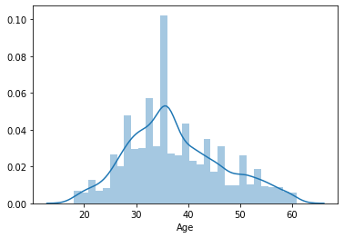

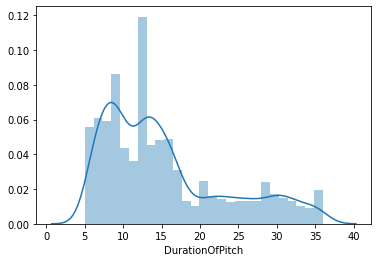

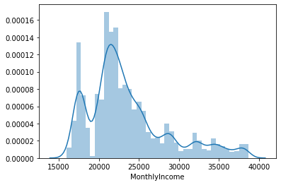

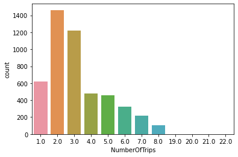

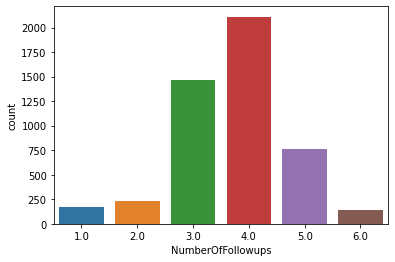

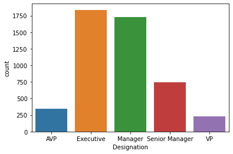

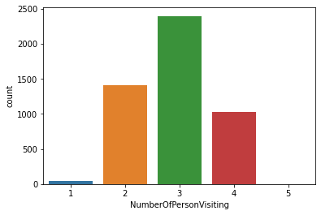

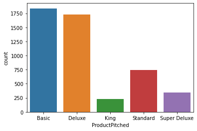

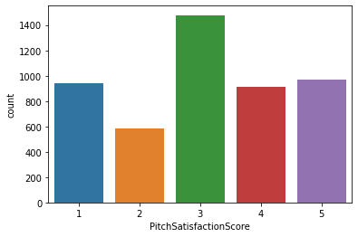

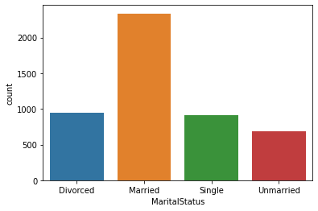

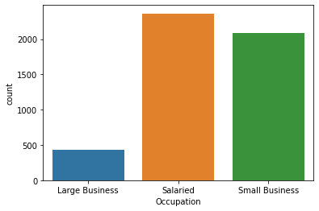

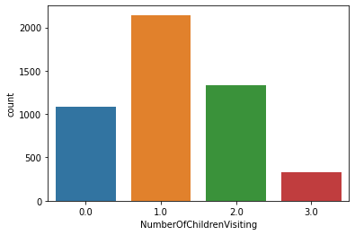

[7 more figures not shown]

```python
distPlotList = ['Age', 'DurationOfPitch','MonthlyIncome']
countPlotList = ['NumberOfTrips','NumberOfFollowups','Designation','NumberOfPersonVisiting',
                'ProductPitched','PitchSatisfactionScore','MaritalStatus','Occupation','NumberOfChildrenVisiting',
                'PreferredPropertyStar','Gender','CityTier','Passport','OwnCar','TypeofContact','ProdTaken']
for i in distPlotList:
    sns.distplot(data[i])
    plt.show()

for i in countPlotList:
    sns.countplot(data[i])
    plt.show()
```

### Univariate Conclusion:

1. Average age is 37. It is important to implement tour package that fits the age target.
2. Average monthly income is 23500. It is important to know the customers' budget. (According to Bank of America, typical customers use 5% of their annual income on trip.) reference: https://www.washingtonpost.com/lifestyle/travel/how-to-set-and-stick-to-a-vacation-budget/2020/06/24/a3980212-b49b-11ea-a8da-693df3d7674a_story.html
3. People generally go to 2-3 trips with 2-4 people. It is important to implement tour package that fits this.
4. About 30% of people has passport and about 60% of people has vehicle. It is possible to plan trip abroad or road trips.
5. people either live in tier 1 or tier 3 city. Consider the expectation of hotel quality since they want 3 stars or higher.

## Bivariate EDA

```python
data.corr()
```

|  | ProdTaken | Age | CityTier | DurationOfPitch | NumberOfPersonVisiting | NumberOfFollowups | PreferredPropertyStar | NumberOfTrips | Passport | PitchSatisfactionScore | OwnCar | NumberOfChildrenVisiting | MonthlyIncome |
| --- | --- | --- | --- | --- | --- | --- | --- | --- | --- | --- | --- | --- | --- |
| ProdTaken | 1.000000 | -0.143669 | 0.086929 | 0.081964 | 0.009302 | 0.111682 | 0.098595 | 0.019698 | 0.261654 | 0.051275 | -0.011460 | 0.007770 | -0.130329 |
| Age | -0.143669 | 1.000000 | -0.013228 | -0.010866 | 0.017748 | 0.001582 | -0.015692 | 0.174567 | 0.032650 | 0.017794 | 0.047245 | 0.008123 | 0.483594 |
| CityTier | 0.086929 | -0.013228 | 1.000000 | 0.011511 | -0.001664 | 0.024653 | -0.008111 | -0.028940 | 0.003096 | -0.041133 | 0.003206 | -0.000114 | 0.057656 |
| DurationOfPitch | 0.081964 | -0.010866 | 0.011511 | 1.000000 | 0.078892 | 0.017378 | -0.001677 | 0.013866 | 0.039282 | 0.006268 | -0.007280 | 0.037071 | 0.008890 |
| NumberOfPersonVisiting | 0.009302 | 0.017748 | -0.001664 | 0.078892 | 1.000000 | 0.324810 | 0.029986 | 0.190012 | 0.011764 | -0.019817 | 0.010439 | 0.606140 | 0.209633 |
| NumberOfFollowups | 0.111682 | 0.001582 | 0.024653 | 0.017378 | 0.324810 | 1.000000 | -0.027568 | 0.135401 | 0.003991 | 0.004656 | 0.011901 | 0.281671 | 0.178729 |
| PreferredPropertyStar | 0.098595 | -0.015692 | -0.008111 | -0.001677 | 0.029986 | -0.027568 | 1.000000 | 0.009757 | 0.001159 | -0.023921 | 0.013276 | 0.031140 | -0.005295 |
| NumberOfTrips | 0.019698 | 0.174567 | -0.028940 | 0.013866 | 0.190012 | 0.135401 | 0.009757 | 1.000000 | 0.013144 | -0.005124 | -0.011554 | 0.160854 | 0.127316 |
| Passport | 0.261654 | 0.032650 | 0.003096 | 0.039282 | 0.011764 | 0.003991 | 0.001159 | 0.013144 | 1.000000 | 0.002137 | -0.021845 | 0.021402 | -0.003371 |
| PitchSatisfactionScore | 0.051275 | 0.017794 | -0.041133 | 0.006268 | -0.019817 | 0.004656 | -0.023921 | -0.005124 | 0.002137 | 1.000000 | 0.070438 | 0.000686 | 0.036961 |
| OwnCar | -0.011460 | 0.047245 | 0.003206 | -0.007280 | 0.010439 | 0.011901 | 0.013276 | -0.011554 | -0.021845 | 0.070438 | 1.000000 | 0.025405 | 0.075500 |
| NumberOfChildrenVisiting | 0.007770 | 0.008123 | -0.000114 | 0.037071 | 0.606140 | 0.281671 | 0.031140 | 0.160854 | 0.021402 | 0.000686 | 0.025405 | 1.000000 | 0.201802 |
| MonthlyIncome | -0.130329 | 0.483594 | 0.057656 | 0.008890 | 0.209633 | 0.178729 | -0.005295 | 0.127316 | -0.003371 | 0.036961 | 0.075500 | 0.201802 | 1.000000 |

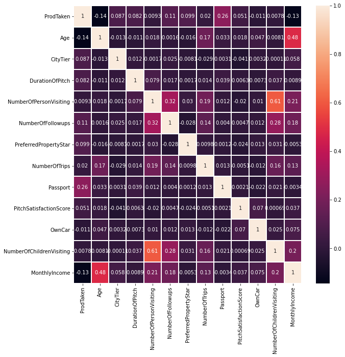

```python
plt.subplots(figsize=(10,10))
sns.heatmap(data.corr(), annot =True, linewidth=1)
```

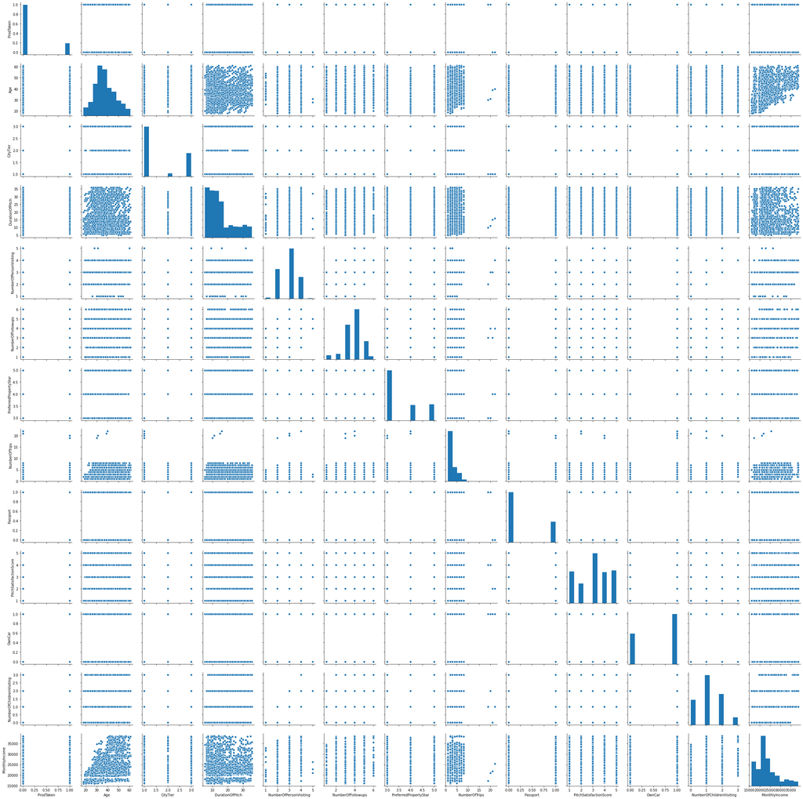

```python
sns.pairplot(data)
```

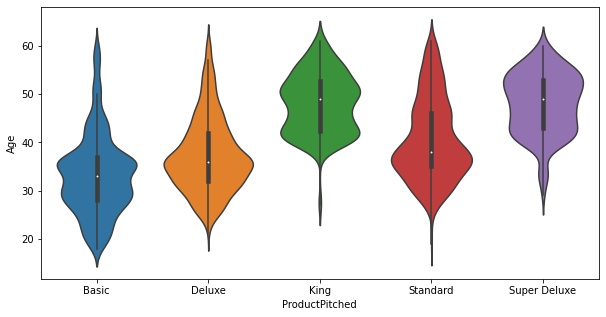

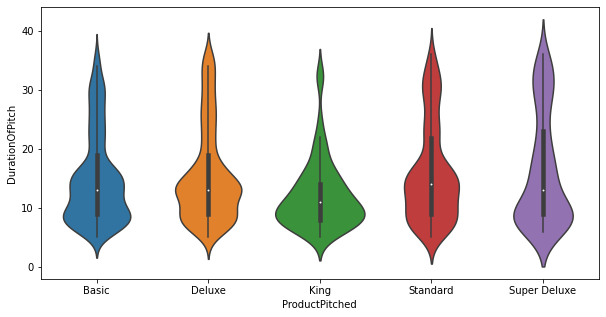

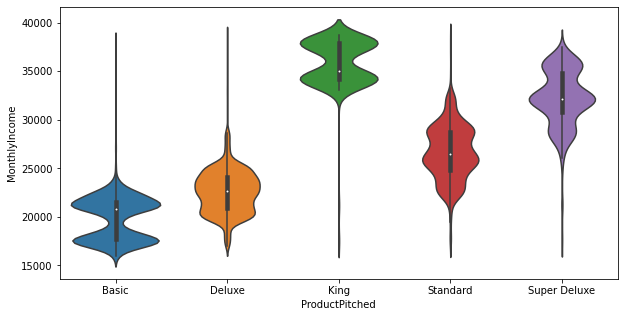

```python
for i in distPlotList:
    plt.figure(figsize=(10,5))
    sns.violinplot(x=data['ProductPitched'], y=data[i])
    plt.show()
```

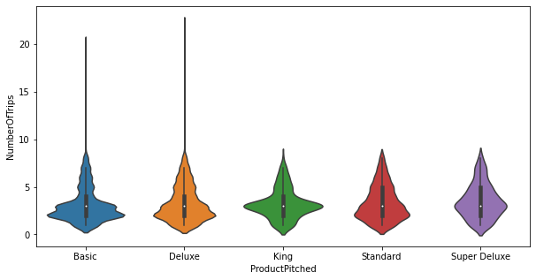

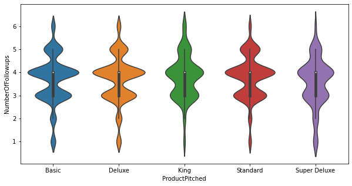

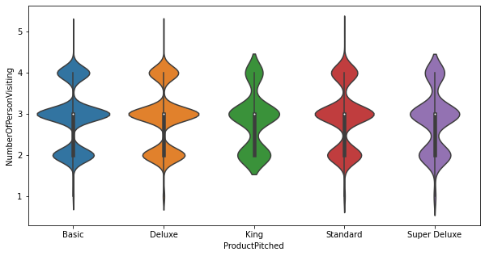

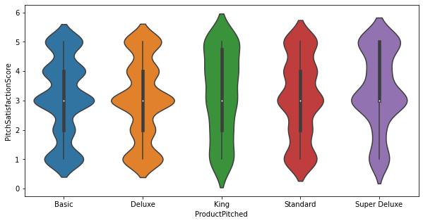

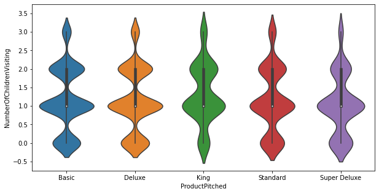

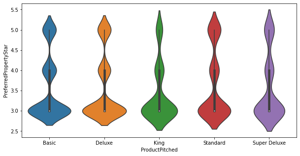

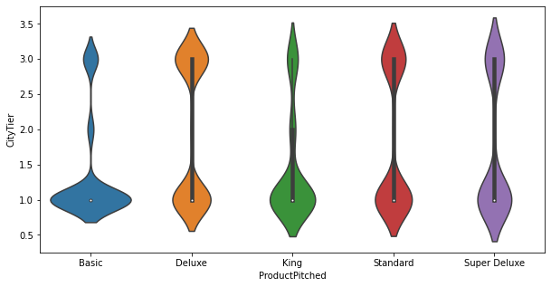

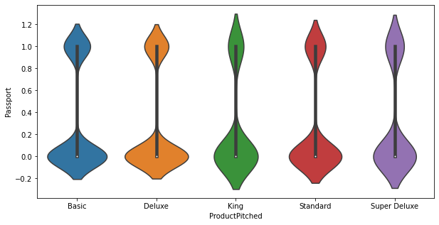

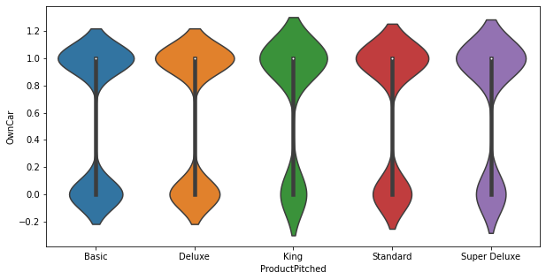

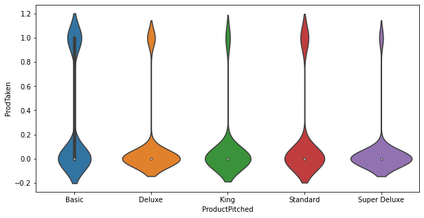

```python
numericalPlotList = ['NumberOfTrips','NumberOfFollowups','NumberOfPersonVisiting',
                'PitchSatisfactionScore','NumberOfChildrenVisiting',
                'PreferredPropertyStar','CityTier','Passport','OwnCar','ProdTaken']

for i in numericalPlotList:
    plt.figure(figsize=(10,5))
    sns.violinplot(x=data['ProductPitched'], y=data[i])
    plt.show()
```

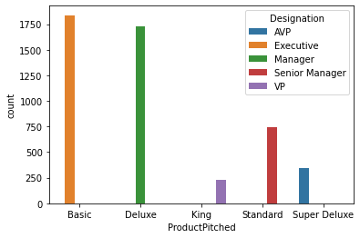

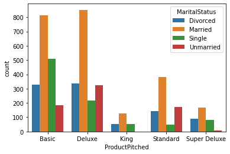

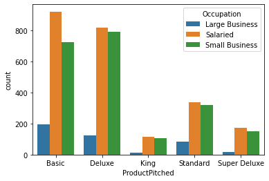

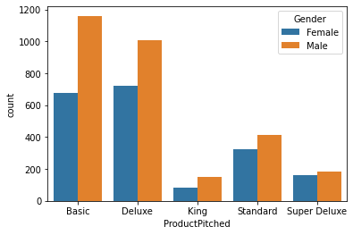

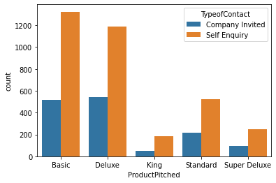

```python
categoricalPlotList = ['Designation', 'MaritalStatus', 'Occupation','Gender', 'TypeofContact']
for i in categoricalPlotList:
    sns.countplot(data['ProductPitched'], hue = data[i])
    plt.show()
```

```python
data[data['Designation']=='AVP']['ProductPitched'].unique()
```

```
[Super Deluxe]
Categories (1, object): [Super Deluxe]
```

### Bivariate Conclusion:

Before going into model making, it is more important to secure recall rate in this particular case. For the sake of project, assume missing potential cutomer is 4 times more costly than marketing costs. Hence, recall is 4 times more valuable than precision.

## Data Split

```python
X = data.drop(['ProdTaken'],axis=1)
X = pd.get_dummies(X,drop_first=True)
y = data['ProdTaken']
```

```python
x_train, x_test, y_train, y_test =train_test_split(X, y, test_size=0.3, random_state=1,stratify=y)
print(x_train.shape, x_test.shape)
```

```
(3417, 27) (1465, 27)
```

```python
print("Class distritution: ")
print(y.value_counts(1))
print("")
print("Test Class distritution: ") # good distribution
print(y_test.value_counts(1))
```

```
Class distritution:
0    0.811553
1    0.188447
Name: ProdTaken, dtype: float64

Test Class distritution:
0    0.811604
1    0.188396
Name: ProdTaken, dtype: float64
```

## Function Implementaion

```python
def get_score_acc_rec_prec(model):
    '''
    model : Classifier to predict
    [0:train_acc,1:test_acc,2:train_recall,3:test_recall,4:train_precision,5test_precision]
    '''

    list = [] # defining an empty list to store all scores

    pred_train = model.predict(x_train)
    pred_test = model.predict(x_test)

    #Create Scores
    train_acc = model.score(x_train,y_train)
    test_acc = model.score(x_test,y_test)
    train_recall = metrics.recall_score(y_train,pred_train)
    test_recall = metrics.recall_score(y_test,pred_test)
    train_precision = metrics.precision_score(y_train,pred_train)
    test_precision = metrics.precision_score(y_test,pred_test)

    # Add accuracy in the list
    list.append(train_acc)
    list.append(test_acc)
    list.append(train_recall)
    list.append(test_recall)
    list.append(train_precision)
    list.append(test_precision)

    return list # returning the list with train and test scores
```

```python
def print_score(list,what="all"):
    ''''''
    if what == "acc":
        print("Accuracy on training set : ", list[0])
        print("Accuracy on test set : ", list[1])
    elif what == "rec":
        print("Recall on training set : ", list[2])
        print("Recall on test set : ", list[3])
    elif what == "prec":
        print("Precision on training set : ", list[4])
        print("Precision on test set : ", list[5])
    else:
        print("Accuracy on training set : ", list[0])
        print("Accuracy on test set : ", list[1])
        print("Recall on training set : ", list[2])
        print("Recall on test set : ", list[3])
        print("Precision on training set : ", list[4])
        print("Precision on test set : ", list[5])
```

```python
def make_cm(model,y_actual,labels=[1, 0]):
    '''
    model : classifier to predict
    y_actual : ground truth (y_test)

    '''

    y_predict = model.predict(x_test)
    cm=metrics.confusion_matrix( y_actual, y_predict, labels=[1, 0])
    df_cm = pd.DataFrame(cm, index = [i for i in ["1","0"]],
                  columns = [i for i in ["Predict 1","Predict 0"]])

#     annotation=[cm]
# [['1116\n76.18%' '73\n4.98%']
#  ['91\n6.21%' '185\n12.63%']]
    sns.heatmap(df_cm, annot=True, fmt='')
```